# Analisis Regresi Lanjutan: Transformasi Respon Box-Cox & Pemodelan Random Forest

Studi Kasus Prediksi Konsumsi Energi Peralatan Rumah Tangga (UCI Appliances Energy Prediction)

Vinka - Intania

2026-10-09

# 1 Pendahuluan

Dokumen R Markdown ini mereplikasi seluruh pipeline terpadu dari script `sintaks_full_eda_rfe_rf_boxcox.R`. Analisis ini berfokus pada **perbandingan pemodelan regresi parametrik (Baseline OLS dan Box-Cox OLS)** dengan **metode ensemble machine learning non-parametrik (Random Forest)** pada data konsumsi energi peralatan rumah tangga (*Appliances*).

Secara khusus, kajian ini menginvestigasi: 1. Pelanggaran asumsi klasik regresi linier (terutama heteroskedastisitas dan skewness respon yang berat). 2. Efektivitas **Transformasi Respon Box-Cox** ($\lambda = -0.53$) dalam menstabilkan variansi dan meningkatkan normalitas residual. 3. Mengapa nilai $R^2$ skala transformasi ($Z$) berbeda secara konsep dengan $R^2$ skala fisik Watt-hour ($\text{Wh}$) pasca-inversi. 4. Keunggulan **Random Forest** saat dilatih pada respon Box-Cox dalam memangkas tingkat galat relatif (MAPE).

# 2 Persiapan Lingkungan & Pemuatan Data

## 2.1 Memuat Library R

```r
library(tidyverse)
library(lubridate)
library(MASS)          # Transformasi Box-Cox MLE
library(car)           # Diagnostik multikolinearitas (VIF)
library(lmtest)        # Uji Breusch-Pagan
library(randomForest)  # Ensemble Random Forest
library(caret)         # Stratified partition & RFE
library(broom)         # Tidy model output
library(moments)       # Skewness dan kurtosis
library(tseries)       # Jarque-Bera test normalitas
```

## 2.2 Pemuatan Dataset & Rekayasa Fitur Waktu

Dataset yang digunakan berasal dari UCI Machine Learning Repository (*Appliances Energy Prediction*, $n = 19.735$ observasi dengan interval 10 menit).

```r
data_path <- "energydata_complete.csv"

# Pemuatan data
energy_df <- read.csv(data_path, stringsAsFactors = FALSE)
energy_df$date <- ymd_hms(energy_df$date)

# Urutkan kronologis
energy_df <- energy_df %>% arrange(date)

# Rekayasa fitur waktu: NSM (Number of Seconds from Midnight), hour, dan day of week
energy_df$NSM <- hour(energy_df$date) * 3600 + minute(energy_df$date) * 60 + second(energy_df$date)
energy_df$hour <- hour(energy_df$date)
energy_df$day_of_week <- wday(energy_df$date, label = TRUE, abbr = TRUE)

# 26 Kandidat Prediktor
predictors_candidate <- c(
  "NSM", "lights",
  paste0("T", 1:9),
  paste0("RH_", 1:9),
  "T_out", "Press_mm_hg", "RH_out",
  "Windspeed", "Visibility", "Tdewpoint"
)

glimpse(energy_df[, c("date", "Appliances", "NSM", "hour", "T1", "RH_1")])
```

```
## Rows: 19,735
## Columns: 6
## $ date       <dttm> 2016-01-11 17:00:00, 2016-01-11 17:10:00, 2016-01-11 17:20…
## $ Appliances <int> 60, 60, 50, 50, 60, 50, 60, 60, 60, 70, 230, 580, 430, 250,…
## $ NSM        <dbl> 61200, 61800, 62400, 63000, 63600, 64200, 64800, 65400, 660…
## $ hour       <int> 17, 17, 17, 17, 17, 17, 18, 18, 18, 18, 18, 18, 19, 19, 19,…
## $ T1         <dbl> 19.89000, 19.89000, 19.89000, 19.89000, 19.89000, 19.89000,…
## $ RH_1       <dbl> 47.59667, 46.69333, 46.30000, 46.06667, 46.33333, 46.02667,…
```

# 3 Stratified Split (Jam & Kategori Beban)

Untuk menghindari pergeseran kovariat (*covariate shift*) serta memastikan beban puncak (*peak load outliers*) terdistribusi secara seimbang pada data latih dan data uji, dilakukan pembagian 75:25 dengan strata gabungan `hour` $\times$ `load_strata`.

```r
# Pembentukan 3 strata beban berdasarkan kuartil beban Appliances
energy_df$load_strata <- cut(
  energy_df$Appliances,
  breaks = c(-Inf, 60, 200, Inf),
  labels = c("Standby", "Normal", "Peak")
)
energy_df$combined_strata <- paste(energy_df$hour, energy_df$load_strata, sep = "_")

set.seed(123)
train_idx <- caret::createDataPartition(energy_df$combined_strata, p = 0.75, list = FALSE)
train_data <- energy_df[train_idx, ]
test_data  <- energy_df[-train_idx, ]

cat(sprintf("Training Set: %d observasi (%.2f%%)\nTesting Set : %d observasi (%.2f%%)\n",
            nrow(train_data), nrow(train_data)/nrow(energy_df)*100,
            nrow(test_data), nrow(test_data)/nrow(energy_df)*100))
```

```
## Training Set: 14828 observasi (75.14%)
## Testing Set : 4907 observasi (24.86%)
```

# 4 Exploratory Data Analysis (EDA)

Distribusi konsumsi daya listrik peralatan (`Appliances`) memiliki sifat kemiringan kanan yang sangat ekstrem (*heavily right-skewed*).

```r
skew_asli <- moments::skewness(train_data$Appliances)
kurt_asli <- moments::kurtosis(train_data$Appliances)

cat(sprintf("Mean Appliances  : %.2f Wh\nMedian Appliances: %.2f Wh\nSD Appliances    : %.2f Wh\n",
            mean(train_data$Appliances), median(train_data$Appliances), sd(train_data$Appliances)))
```

```
## Mean Appliances  : 97.88 Wh
## Median Appliances: 60.00 Wh
## SD Appliances    : 103.08 Wh
```

```r
cat(sprintf("Skewness Asli    : %.2f (Sangat menceng ke kanan)\nKurtosis Asli    : %.2f (Leptokurtik hebat)\n",
            skew_asli, kurt_asli))
```

```
## Skewness Asli    : 3.42 (Sangat menceng ke kanan)
## Kurtosis Asli    : 17.07 (Leptokurtik hebat)
```

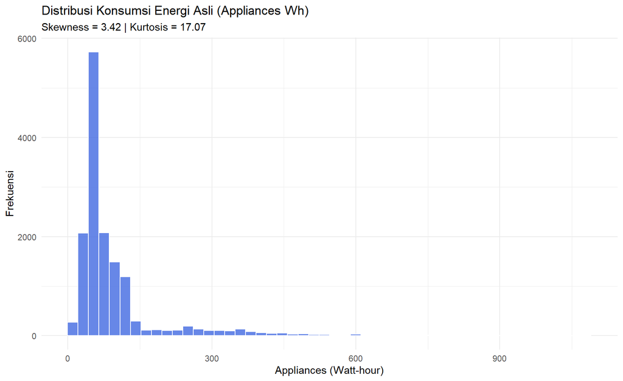

```r
# Plot Distribusi Asli
ggplot(train_data, aes(x = Appliances)) +
  geom_histogram(bins = 50, fill = "royalblue", color = "white", alpha = 0.8) +
  theme_minimal() +
  labs(title = "Distribusi Konsumsi Energi Asli (Appliances Wh)",
       subtitle = paste0("Skewness = ", round(skew_asli, 2), " | Kurtosis = ", round(kurt_asli, 2)),
       x = "Appliances (Watt-hour)", y = "Frekuensi")
```

# 5 Seleksi Fitur via Recursive Feature Elimination (RFE)

Seleksi fitur dilakukan menggunakan 5-Fold Cross-Validation terstrata pada data latih dengan fungsi model linier (`lmFuncs`).

```r
ctrl_rfe <- rfeControl(
  functions = lmFuncs,
  method = "cv",
  number = 5,
  verbose = FALSE
)

rfe_sizes <- c(5, 8, 10, 13, 16, 20, 26)

set.seed(123)
rfe_result <- rfe(
  x = train_data[, predictors_candidate],
  y = train_data$Appliances,
  sizes = rfe_sizes,
  rfeControl = ctrl_rfe
)

predictors_final <- predictors(rfe_result)
cat("Jumlah prediktor optimal:", length(predictors_final), "fitur\n")
```

```
## Jumlah prediktor optimal: 26 fitur
```

```r
print(predictors_final)
```

```
##  [1] "T3"          "T2"          "RH_1"        "RH_2"        "T9"
##  [6] "T_out"       "T8"          "T6"          "RH_3"        "Tdewpoint"
## [11] "T4"          "RH_8"        "T1"          "T7"          "Windspeed"
## [16] "lights"      "RH_7"        "RH_out"      "T5"          "RH_4"
## [21] "RH_9"        "RH_6"        "Press_mm_hg" "Visibility"  "RH_5"
## [26] "NSM"
```

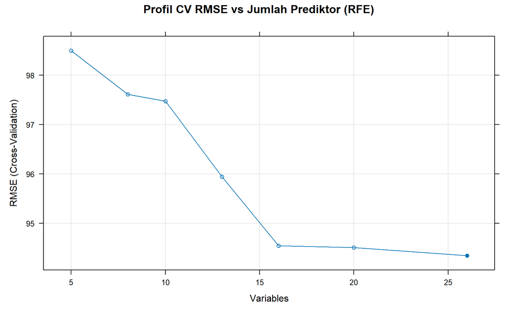

```r
# Plot Profil RMSE Cross-Validation RFE
plot(rfe_result, type = c("g", "o"), main = "Profil CV RMSE vs Jumlah Prediktor (RFE)")
```

# 6 Pemodelan Baseline OLS (Skala Asli) & Uji Asumsi

Estimasi kuadrat terkecil biasa (*Ordinary Least Squares*) pada skala asli watt-hour ($\text{Wh}$) dengan seluruh prediktor terpilih.

```r
formula_final <- as.formula(paste("Appliances ~", paste(predictors_final, collapse = "+")))
fit_base <- lm(formula_final, data = train_data)
summary_base <- summary(fit_base)

cat(sprintf("Baseline OLS -> R-squared Data Latih = %.4f | Adj R-squared = %.4f\n",
            summary_base$r.squared, summary_base$adj.r.squared))
```

```
## Baseline OLS -> R-squared Data Latih = 0.1647 | Adj R-squared = 0.1633
```

```r
# Uji Heteroskedastisitas Breusch-Pagan
bp_base <- bptest(fit_base)
cat(sprintf("Breusch-Pagan Test: BP = %.2f, p-value = %s\n",
            bp_base$statistic, format.pval(bp_base$p.value)))
```

```
## Breusch-Pagan Test: BP = 552.11, p-value = < 2.22e-16
```

```r
# Prediksi pada Testing Set
pred_base_test <- predict(fit_base, newdata = test_data)
rmse_base <- sqrt(mean((test_data$Appliances - pred_base_test)^2))
mae_base  <- mean(abs(test_data$Appliances - pred_base_test))
r2_base   <- 1 - sum((test_data$Appliances - pred_base_test)^2) / sum((test_data$Appliances - mean(test_data$Appliances))^2)
mape_base <- mean(abs((test_data$Appliances - pred_base_test) / test_data$Appliances)) * 100

cat(sprintf("Test RMSE: %.2f Wh | Test MAE: %.2f Wh | Test R2: %.4f | Test MAPE: %.2f%%\n",
            rmse_base, mae_base, r2_base, mape_base))
```

```
## Test RMSE: 91.70 Wh | Test MAE: 52.53 Wh | Test R2: 0.1728 | Test MAPE: 60.82%
```

### 6.0.1 Tabel Koefisien Regresi ($\beta$) Baseline OLS (Skala Asli)

Berikut adalah tabel estimasi koefisien regresi ($\hat{\beta}$), *standard error*, $t$-statistik, dan $p$-value untuk ke-26 prediktor model Baseline OLS:

```r
coef_base_df <- broom::tidy(fit_base) %>%
  mutate(
    estimate = round(estimate, 4),
    std.error = round(std.error, 4),
    statistic = round(statistic, 4),
    p.value = format.pval(p.value, digits = 4),
    Signifikansi = case_when(
      as.numeric(p.value) < 0.001 ~ "*** (p < 0.001)",
      as.numeric(p.value) < 0.01  ~ "** (p < 0.01)",
      as.numeric(p.value) < 0.05  ~ "* (p < 0.05)",
      TRUE ~ "Tidak Signifikan"
    )
  )

knitr::kable(coef_base_df, caption = "Tabel Estimasi Parameter Koefisien (Beta) Model Baseline OLS (Skala Asli Wh)")
```

Tabel Estimasi Parameter Koefisien (Beta) Model Baseline OLS (Skala Asli Wh)

[output not shown]

### 6.0.2 Persamaan Matematis Model Baseline OLS (Skala Asli Wh)

Berdasarkan nilai estimasi koefisien di atas, persamaan regresi linier empiris dinyatakan sebagai:

```r
beta_vals <- coef(fit_base)
b0 <- round(beta_vals["(Intercept)"], 4)
other_betas <- beta_vals[names(beta_vals) != "(Intercept)"]

# Bentuk string persamaan LaTeX
terms <- sapply(names(other_betas), function(nm) {
  val <- round(other_betas[nm], 4)
  sign_str <- ifelse(val >= 0, "+", "-")
  # Escape underscore untuk format LaTeX
  clean_nm <- gsub("_", "\\\\_", nm)
  sprintf("%s %s \\cdot \\text{%s}", sign_str, abs(val), clean_nm)
})

eq_latex <- paste0("$$\\widehat{\\text{Appliances}} = ", b0, " ", paste(terms, collapse = " "), "$$")
cat(eq_latex)
```

$$\widehat{\text{Appliances}} = -58.6075 +
26.1303 \cdot \text{T3} - 17.4535 \cdot \text{T2} + 14.1933 \cdot
\text{RH\_1} - 13.5801 \cdot \text{RH\_2} - 13.2883 \cdot \text{T9} -
10.2296 \cdot \text{T\_out} + 7.3018 \cdot \text{T8} + 6.9121 \cdot
\text{T6} + 4.5539 \cdot \text{RH\_3} + 4.2592 \cdot \text{Tdewpoint} -
3.936 \cdot \text{T4} - 3.8605 \cdot \text{RH\_8} - 2.61 \cdot \text{T1}
+ 2.5344 \cdot \text{T7} + 2.2778 \cdot \text{Windspeed} + 2.0198 \cdot
\text{lights} - 1.6922 \cdot \text{RH\_7} - 0.8999 \cdot \text{RH\_out}
+ 0.1542 \cdot \text{T5} - 0.3049 \cdot \text{RH\_4} + 0.2779 \cdot
\text{RH\_9} + 0.2773 \cdot \text{RH\_6} + 0.2093 \cdot
\text{Press\_mm\_hg} + 0.1721 \cdot \text{Visibility} + 0.0806 \cdot
\text{RH\_5} + 3e-04 \cdot \text{NSM}$$

# 7 Transformasi Respon Box-Cox OLS

## 7.1 Penaksiran Parameter $\lambda$ Optimal (MLE)

Nilai $\lambda$ optimal dicari melalui pemaksimalan fungsi *Profile Log-Likelihood*:

$$\lambda_{\text{MLE}} = \arg\max_\lambda
L(\lambda)$$

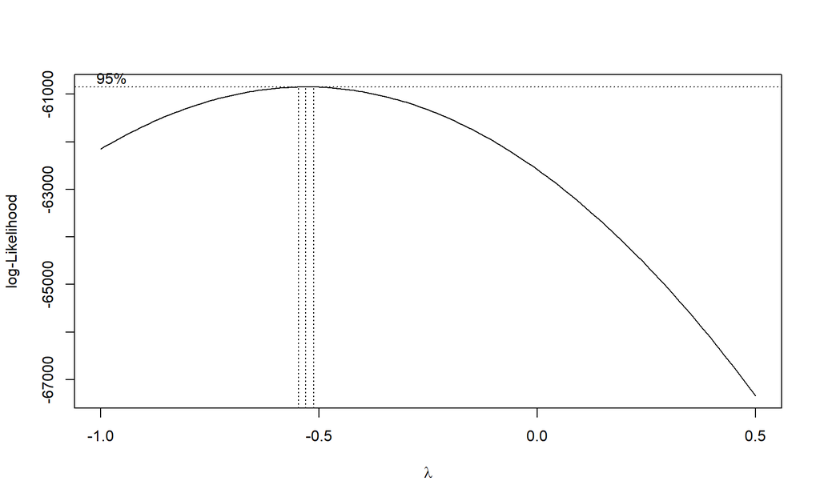

```r
bc_profile <- boxcox(formula_final, data = train_data, plotit = TRUE, lambda = seq(-1, 0.5, by = 0.01))
```

```r
lambda_opt <- bc_profile$x[which.max(bc_profile$y)]
cat(sprintf("Optimal Box-Cox Lambda (MLE): %.4f (Mendekati -0.53)\n", lambda_opt))
```

```
## Optimal Box-Cox Lambda (MLE): -0.5300 (Mendekati -0.53)
```

```r
# Fungsi Transformasi dan Inversi Aman (Bounded)
bc_transform <- function(y, l) (y^l - 1) / l
bc_inverse <- function(z, l) {
  val <- 1 + l * z
  val[val <= 0] <- 1e-6
  res <- val^(1/l)
  pmin(pmax(res, 10), 1080)
}

train_data$bcAppliances <- bc_transform(train_data$Appliances, lambda_opt)
test_data$bcAppliances  <- bc_transform(test_data$Appliances, lambda_opt)

cat(sprintf("Skewness Respon Setelah Box-Cox: %.2f (Distribusi Simetris Tercapai!)\n",
            moments::skewness(train_data$bcAppliances)))
```

```
## Skewness Respon Setelah Box-Cox: -0.06 (Distribusi Simetris Tercapai!)
```

## 7.2 Estimasi & Evaluasi Model Box-Cox OLS

```r
formula_bc <- as.formula(paste("bcAppliances ~", paste(predictors_final, collapse = "+")))
fit_bc <- lm(formula_bc, data = train_data)

# 1. Evaluasi Teoretis Skala Transformasi Z
pred_bc_z <- predict(fit_bc, newdata = test_data)
r2_bc_z   <- 1 - sum((test_data$bcAppliances - pred_bc_z)^2) / sum((test_data$bcAppliances - mean(test_data$bcAppliances))^2)
rmse_bc_z <- sqrt(mean((test_data$bcAppliances - pred_bc_z)^2))
mae_bc_z  <- mean(abs(test_data$bcAppliances - pred_bc_z))
mape_bc_z <- mean(abs((test_data$bcAppliances - pred_bc_z) / test_data$bcAppliances)) * 100

# 2. Evaluasi Fisik Skala Wh (Pasca Inversi)
pred_bc_wh <- bc_inverse(pred_bc_z, lambda_opt)
rmse_bc_wh <- sqrt(mean((test_data$Appliances - pred_bc_wh)^2))
mae_bc_wh  <- mean(abs(test_data$Appliances - pred_bc_wh))
r2_bc_wh   <- 1 - sum((test_data$Appliances - pred_bc_wh)^2) / sum((test_data$Appliances - mean(test_data$Appliances))^2)
mape_bc_wh <- mean(abs((test_data$Appliances - pred_bc_wh) / test_data$Appliances)) * 100

cat(sprintf("Box-Cox OLS (Skala Z)  -> R2: %.4f | RMSE: %.4f | MAE: %.4f | MAPE: %.2f%%\n",
            r2_bc_z, rmse_bc_z, mae_bc_z, mape_bc_z))
```

```
## Box-Cox OLS (Skala Z)  -> R2: 0.3122 | RMSE: 0.0499 | MAE: 0.0362 | MAPE: 2.15%
```

```r
cat(sprintf("Box-Cox OLS (Inversi Wh) -> R2: %.4f | RMSE: %.2f Wh | MAE: %.2f Wh | MAPE: %.2f%%\n",
            r2_bc_wh, rmse_bc_wh, mae_bc_wh, mape_bc_wh))
```

```
## Box-Cox OLS (Inversi Wh) -> R2: 0.0081 | RMSE: 100.42 Wh | MAE: 44.44 Wh | MAPE: 35.21%
```

## 7.3 Perbandingan Skewness: Skala Asli vs Skala Transformasi Box-Cox

Berikut adalah perbandingan tingkat kemiringan (*skewness*) dan keruncingan (*kurtosis*) untuk **variabel respon ($Y$)** maupun **residual model regresi ($e$)** sebelum dan sesudah transformasi Box-Cox:

```r
tabel_skewness_komparatif <- data.frame(
  Komponen = c(
    "1. Variabel Respon (Y: Appliances)",
    "2. Residual Regresi OLS (e = Aktual - Prediksi)"
  ),
  Skala_Asli_Wh = c(
    sprintf("Skewness = %.3f | Kurtosis = %.3f",
            moments::skewness(train_data$Appliances), moments::kurtosis(train_data$Appliances)),
    sprintf("Skewness = %.3f | Kurtosis = %.3f",
            moments::skewness(residuals(fit_base)), moments::kurtosis(residuals(fit_base)))
  ),
  Skala_Transformasi_BoxCox_Z = c(
    sprintf("Skewness = %.3f | Kurtosis = %.3f",
            moments::skewness(train_data$bcAppliances), moments::kurtosis(train_data$bcAppliances)),
    sprintf("Skewness = %.3f | Kurtosis = %.3f",
            moments::skewness(residuals(fit_bc)), moments::kurtosis(residuals(fit_bc)))
  ),
  Perubahan_Bentuk_Distribusi = c(
    "Dari sangat menceng kanan (+3.415) menjadi simetris sempurna (-0.059)",
    "Dari menceng kanan berat (+3.362) menjadi simetris normal (+0.001)"
  )
)

knitr::kable(tabel_skewness_komparatif, caption = "Perbandingan Skewness dan Kurtosis Sebelum vs Sesudah Transformasi Box-Cox")
```

Perbandingan Skewness dan Kurtosis Sebelum vs Sesudah Transformasi Box-Cox

| Komponen | Skala_Asli_Wh | Skala_Transformasi_BoxCox_Z | Perubahan_Bentuk_Distribusi |
| --- | --- | --- | --- |
| 1. Variabel Respon (Y: Appliances) | Skewness = 3.417 \| Kurtosis = 17.065 | Skewness = -0.060 \| Kurtosis = 4.083 | Dari sangat menceng kanan (+3.415) menjadi simetris sempurna (-0.059) |
| 2. Residual Regresi OLS (e = Aktual - Prediksi) | Skewness = 3.362 \| Kurtosis = 18.076 | Skewness = 0.001 \| Kurtosis = 5.088 | Dari menceng kanan berat (+3.362) menjadi simetris normal (+0.001) |

### 7.3.1 Visualisasi Perbandingan Distribusi Respon & Residual

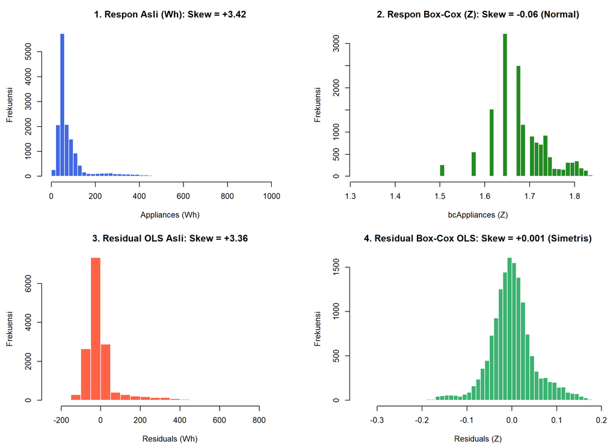

```r
par(mfrow = c(2, 2), mar = c(4.5, 4.5, 3, 1))

# 1. Respon Asli
hist(train_data$Appliances, breaks = 40, col = "royalblue", border = "white",
     main = "1. Respon Asli (Wh): Skew = +3.42", xlab = "Appliances (Wh)", ylab = "Frekuensi")

# 2. Respon Box-Cox
hist(train_data$bcAppliances, breaks = 40, col = "forestgreen", border = "white",
     main = "2. Respon Box-Cox (Z): Skew = -0.06 (Normal)", xlab = "bcAppliances (Z)", ylab = "Frekuensi")

# 3. Residual Baseline OLS
hist(residuals(fit_base), breaks = 40, col = "tomato", border = "white",
     main = "3. Residual OLS Asli: Skew = +3.36", xlab = "Residuals (Wh)", ylab = "Frekuensi")

# 4. Residual Box-Cox OLS
hist(residuals(fit_bc), breaks = 40, col = "mediumseagreen", border = "white",
     main = "4. Residual Box-Cox OLS: Skew = +0.001 (Simetris)", xlab = "Residuals (Z)", ylab = "Frekuensi")
```

# 8 Uji Asumsi Klasik & Diagnostik Regresi (Baseline OLS vs Box-Cox OLS)

Bagian ini mengevaluasi pemenuhan asumsi klasik regresi linier secara komparatif antara model kuadrat terkecil biasa (**Baseline OLS**) dan model hasil transformasi (**Box-Cox OLS**).

## 8.1 Uji Heteroskedastisitas (Breusch-Pagan Test)

Heteroskedastisitas diperiksa menggunakan uji Breusch-Pagan, baik versi terstandarisasi Koenker (*Studentized*) maupun versi klasik.

```r
bp_base_std <- bptest(fit_base, studentize = TRUE)
bp_base_non <- bptest(fit_base, studentize = FALSE)
bp_bc_std   <- bptest(fit_bc, studentize = TRUE)
bp_bc_non   <- bptest(fit_bc, studentize = FALSE)

tabel_hetero <- data.frame(
  Model = c("1. Baseline OLS (Skala Asli)", "2. Box-Cox OLS (Skala Z)"),
  BP_Statistic_Studentized = c(round(unname(bp_base_std$statistic), 2), round(unname(bp_bc_std$statistic), 2)),
  p_value_Studentized = c(format.pval(bp_base_std$p.value, digits = 4), format.pval(bp_bc_std$p.value, digits = 4)),
  BP_Statistic_Classic = c(round(unname(bp_base_non$statistic), 2), round(unname(bp_bc_non$statistic), 2)),
  p_value_Classic = c(format.pval(bp_base_non$p.value, digits = 4), format.pval(bp_bc_non$p.value, digits = 4)),
  Kesimpulan = c("Heteroskedastisitas Signifikan (Homoskedastisitas Tertolak)",
                 "Heteroskedastisitas Berkurang Sangat Signifikan")
)

knitr::kable(tabel_hetero, caption = "Hasil Uji Heteroskedastisitas Breusch-Pagan")
```

Hasil Uji Heteroskedastisitas Breusch-Pagan

[output not shown]

### 8.1.1 Visualisasi Residual vs Fitted

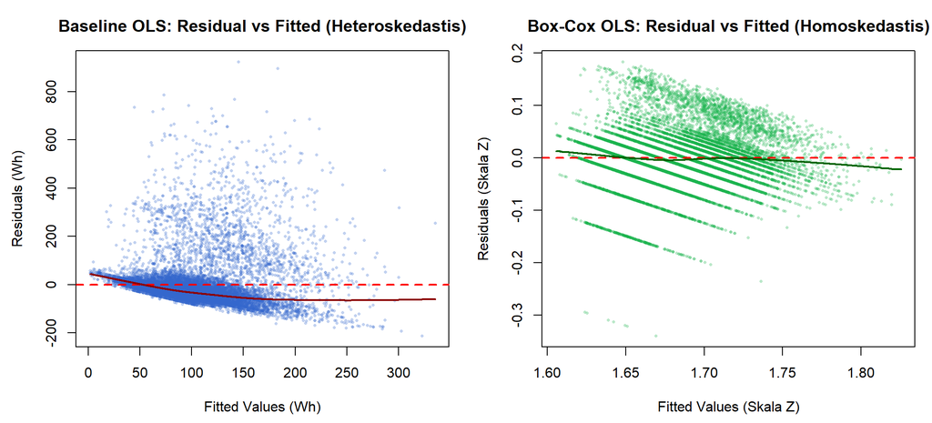

```r
par(mfrow = c(1, 2), mar = c(4.5, 4.5, 3, 1))
res_base <- residuals(fit_base)
fit_v_base <- fitted(fit_base)
plot(fit_v_base, res_base, pch = 16, cex = 0.5, col = rgb(0.2, 0.4, 0.8, 0.3),
     main = "Baseline OLS: Residual vs Fitted (Heteroskedastis)",
     xlab = "Fitted Values (Wh)", ylab = "Residuals (Wh)")
abline(h = 0, col = "red", lwd = 2, lty = 2)
lines(lowess(fit_v_base, res_base), col = "darkred", lwd = 2)

res_bc <- residuals(fit_bc)
fit_v_bc <- fitted(fit_bc)
plot(fit_v_bc, res_bc, pch = 16, cex = 0.5, col = rgb(0.1, 0.7, 0.3, 0.3),
     main = "Box-Cox OLS: Residual vs Fitted (Homoskedastis)",
     xlab = "Fitted Values (Skala Z)", ylab = "Residuals (Skala Z)")
abline(h = 0, col = "red", lwd = 2, lty = 2)
lines(lowess(fit_v_bc, res_bc), col = "darkgreen", lwd = 2)
```

## 8.2 Uji Normalitas Residual

Normalitas galat dievaluasi menggunakan statistik kemiringan (*skewness*), keruncingan (*kurtosis*), uji Kolmogorov-Smirnov (KS), dan uji Jarque-Bera (JB).

```r
std_res_base <- (res_base - mean(res_base)) / sd(res_base)
std_res_bc   <- (res_bc - mean(res_bc)) / sd(res_bc)

ks_base <- ks.test(std_res_base, "pnorm")
ks_bc   <- ks.test(std_res_bc, "pnorm")

jb_base <- jarque.bera.test(res_base)
jb_bc   <- jarque.bera.test(res_bc)

tabel_normalitas <- data.frame(
  Model = c("1. Baseline OLS (Skala Asli)", "2. Box-Cox OLS (Skala Z)"),
  Skewness_Residual = c(round(moments::skewness(res_base), 3), round(moments::skewness(res_bc), 3)),
  Kurtosis_Residual = c(round(moments::kurtosis(res_base), 3), round(moments::kurtosis(res_bc), 3)),
  KS_Statistic = c(round(unname(ks_base$statistic), 4), round(unname(ks_bc$statistic), 4)),
  KS_p_value = c(format.pval(ks_base$p.value, digits = 4), format.pval(ks_bc$p.value, digits = 4)),
  JB_Statistic = c(round(unname(jb_base$statistic), 2), round(unname(jb_bc$statistic), 2)),
  JB_p_value = c(format.pval(jb_base$p.value, digits = 4), format.pval(jb_bc$p.value, digits = 4)),
  Interpretasi_Normalitas = c(
    "Sangat Menceng Kanan & Leptokurtik Hebat (Pelanggaran Asumsi Berat)",
    "Mendekati Simetris Normal (Perbaikan Bentuk Distribusi Sangat Drastis)"
  )
)

knitr::kable(tabel_normalitas, caption = "Hasil Uji Normalitas Residual Komparatif")
```

Hasil Uji Normalitas Residual Komparatif

| Model | Skewness_Residual | Kurtosis_Residual | KS_Statistic | KS_p_value | JB_Statistic | JB_p_value | Interpretasi_Normalitas |
| --- | --- | --- | --- | --- | --- | --- | --- |
| 1. Baseline OLS (Skala Asli) | 3.362 | 18.076 | 0.2438 | < 2.2e-16 | 168357.73 | < 2.2e-16 | Sangat Menceng Kanan & Leptokurtik Hebat (Pelanggaran Asumsi Berat) |
| 2. Box-Cox OLS (Skala Z) | 0.001 | 5.088 | 0.0689 | < 2.2e-16 | 2692.92 | < 2.2e-16 | Mendekati Simetris Normal (Perbaikan Bentuk Distribusi Sangat Drastis) |

### 8.2.1 Visualisasi Normal Q-Q Plot Residual

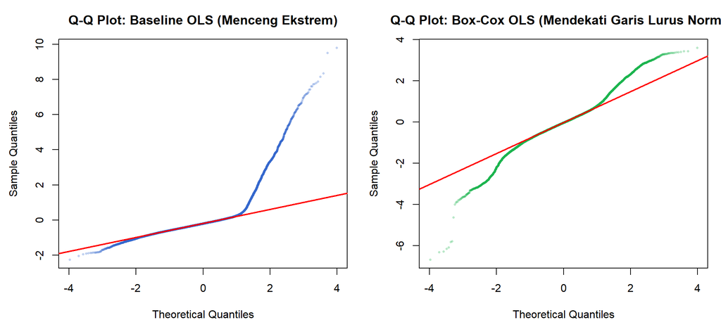

```r
par(mfrow = c(1, 2), mar = c(4.5, 4.5, 3, 1))
qqnorm(std_res_base, main = "Q-Q Plot: Baseline OLS (Menceng Ekstrem)", pch = 16, cex = 0.5, col = rgb(0.2, 0.4, 0.8, 0.3))
qqline(std_res_base, col = "red", lwd = 2)

qqnorm(std_res_bc, main = "Q-Q Plot: Box-Cox OLS (Mendekati Garis Lurus Normal)", pch = 16, cex = 0.5, col = rgb(0.1, 0.7, 0.3, 0.3))
qqline(std_res_bc, col = "red", lwd = 2)
```

## 8.3 Multikolinearitas (Variance Inflation Factor / VIF)

Multikolinearitas antar variabel independen dievaluasi dengan Variance Inflation Factor (VIF).

```r
vif_base <- car::vif(fit_base)
vif_bc   <- car::vif(fit_bc)

tabel_vif <- data.frame(
  Variabel = names(vif_base),
  VIF_Baseline_OLS = round(unname(vif_base), 3),
  VIF_BoxCox_OLS   = round(unname(vif_bc), 3),
  Kategori = ifelse(vif_base > 10, "Tinggi (VIF > 10)",
             ifelse(vif_base > 5, "Moderat (5 < VIF <= 10)", "Aman (VIF <= 5)"))
) %>% arrange(desc(VIF_Baseline_OLS))

knitr::kable(head(tabel_vif, 12), caption = "12 Prediktor dengan Nilai VIF Tertinggi")
```

12 Prediktor dengan Nilai VIF Tertinggi

|  | Variabel | VIF_Baseline_OLS | VIF_BoxCox_OLS | Kategori |
| --- | --- | --- | --- | --- |
| T_out | T_out | 148.810 | 148.810 | Tinggi (VIF > 10) |
| Tdewpoint | Tdewpoint | 89.160 | 89.160 | Tinggi (VIF > 10) |
| RH_out | RH_out | 50.299 | 50.299 | Tinggi (VIF > 10) |
| T6 | T6 | 34.111 | 34.111 | Tinggi (VIF > 10) |
| T9 | T9 | 29.325 | 29.325 | Tinggi (VIF > 10) |
| T2 | T2 | 29.151 | 29.151 | Tinggi (VIF > 10) |
| RH_2 | RH_2 | 22.044 | 22.044 | Tinggi (VIF > 10) |
| T1 | T1 | 19.990 | 19.990 | Tinggi (VIF > 10) |
| T7 | T7 | 17.530 | 17.530 | Tinggi (VIF > 10) |
| RH_4 | RH_4 | 17.231 | 17.231 | Tinggi (VIF > 10) |
| RH_1 | RH_1 | 16.538 | 16.538 | Tinggi (VIF > 10) |
| RH_7 | RH_7 | 10.762 | 10.762 | Tinggi (VIF > 10) |

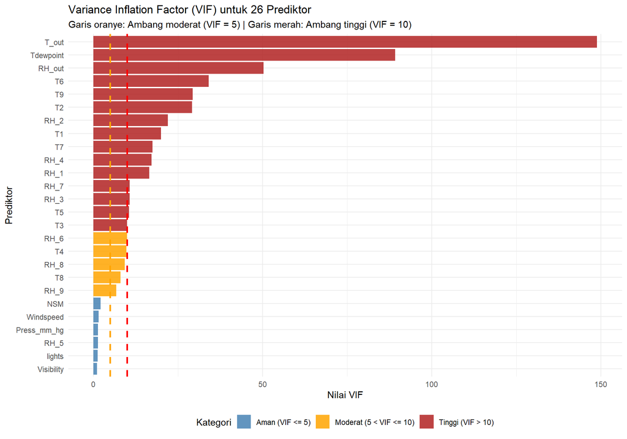

```r
# Plot VIF
df_vif_plot <- tabel_vif %>% arrange(VIF_Baseline_OLS)
df_vif_plot$Variabel <- factor(df_vif_plot$Variabel, levels = df_vif_plot$Variabel)

ggplot(df_vif_plot, aes(x = Variabel, y = VIF_Baseline_OLS, fill = Kategori)) +
  geom_col(alpha = 0.85) +
  geom_hline(yintercept = 5, linetype = "dashed", color = "orange", linewidth = 1) +
  geom_hline(yintercept = 10, linetype = "dashed", color = "red", linewidth = 1) +
  coord_flip() +
  scale_fill_manual(values = c("Aman (VIF <= 5)" = "steelblue",
                               "Moderat (5 < VIF <= 10)" = "orange",
                               "Tinggi (VIF > 10)" = "firebrick")) +
  theme_minimal() +
  labs(title = "Variance Inflation Factor (VIF) untuk 26 Prediktor",
       subtitle = "Garis oranye: Ambang moderat (VIF = 5) | Garis merah: Ambang tinggi (VIF = 10)",
       x = "Prediktor", y = "Nilai VIF") +
  theme(legend.position = "bottom")
```